# ADSP 31013 IP01 Big Data and Cloud Computing

## Group Project – NYC Yellow Taxi Trips (2024/01/01 – 2025/10/15)

### NYC Yellow Taxi Trips – **Tip Rate Classification Model Training**

This notebook presents the **classification model development pipeline** for **Group 8**. While our previous work focused on predicting the raw fare amount (Regression), this analysis pivots to understanding **passenger tipping behavior** (Classification).

**Business Context: Why Classify Tip Rates?**

Understanding tipping behavior is distinct from predicting the fare. While the fare is determined by distance and regulation, the tip is a behavioral signal reflecting passenger satisfaction, cultural norms, and economic sentiment.

Classifying trips into "Tip Tiers" (e.g., No Tip vs. Generous Tip) supports:

- **Driver Incentives:** Identifying trip characteristics (route, weather, time) highly correlated with "Generous" tipping to optimize driver dispatch.
- **Customer Segmentation:** Profiling high-value passengers for loyalty programs.
- **Service Quality Monitoring:** A "No Tip" prediction might indicate routes or conditions prone to poor customer experiences (e.g., high congestion).

**Business Problem – Multiclass Classification**

The objective is to predict the **Tip Rate Category** of a trip based on pre-payment information.

- **Class 0 (No Tip):** Tip Rate = 0%
- **Class 1 (Low):** 0% < Tip Rate < 5%
- **Class 2 (Medium-low):** 5% ≤ Tip Rate < 10%
- **Class 3 (Standard):** 10% ≤ Tip Rate < 15%
- **Class 4 (Medium-high):** 15% ≤ Tip Rate < 20%
- **Class 5 (High):** 20% ≤ Tip Rate < 25%
- **Class 6 (Generous):** Tip Rate ≥ 25%

**Modeling Approach (PySpark MLlib)**

We employ the same rigorous engineering standards as our regression pipeline:

1. **Label Engineering:** Computing rates and handling edge cases (e.g., zero fares).
2. **Feature Engineering:** Reusing our robust **Weather Binning** and **Spatial Encoding** pipelines.
3. **Model Selection:**
   - **Logistic Regression (Multinomial):** For baseline performance and interpretability (odds ratios).
   - **Random Forest Classifier:** To capture non-linear interactions between weather, location, and tipping behavior.
4. **Evaluation:**
- Accuracy (overall hit rate)
- **Weighted F1-Score** (crucial for handling class imbalance)
- Confusion Matrix Analysis

### **0. Environment Setup and Spark Session**

We import the necessary Spark MLlib classification and evaluation components.

```python
from pyspark.sql import SparkSession
from pyspark.sql import functions as F
from pyspark.sql.types import FloatType, IntegerType

from pyspark.sql.functions import broadcast

from pyspark.ml import Pipeline, Transformer
from pyspark.ml.util import DefaultParamsReadable, DefaultParamsWritable
from pyspark.ml.feature import StringIndexer, OneHotEncoder, VectorAssembler, StandardScaler

from pyspark.ml.classification import LogisticRegression, RandomForestClassifier, RandomForestClassificationModel

from pyspark.ml.evaluation import MulticlassClassificationEvaluator
from pyspark.mllib.evaluation import MulticlassMetrics

from pyspark.ml.tuning import ParamGridBuilder, TrainValidationSplit

import seaborn as sns
import matplotlib.pyplot as plt
```

```python
from IPython.core.display import HTML
display(HTML("<style>pre { white-space: pre !important; }</style>"))
```

```python
spark = SparkSession.builder.appName("NYC-Taxi-Tip-Classification").getOrCreate()
```

### **1. Data Loading & Sanity Checks**

We load the same cleaned, weather-enriched dataset used in the regression workflow.

```python
bucket_url = "gs://msca-bdp-student-gcs/group_8_project/datasets/"

df = spark.read.parquet(bucket_url + "cleaned/parquet/")
print(f"Total records loaded: {df.count():,}")
df.printSchema()
```

```
[Stage 1:============================================>            (25 + 7) / 32]
```

```
Total records loaded: 58,866,036
root
 |-- tpep_pickup_datetime: timestamp (nullable = true)
 |-- tpep_dropoff_datetime: timestamp (nullable = true)
 |-- pu_location_id: integer (nullable = true)
 |-- do_location_id: integer (nullable = true)
 |-- pu_borough: string (nullable = true)
 |-- pu_zone: string (nullable = true)
 |-- do_borough: string (nullable = true)
 |-- do_zone: string (nullable = true)
 |-- vendor_id: integer (nullable = true)
 |-- ratecode_id: integer (nullable = true)
 |-- passenger_count: integer (nullable = true)
 |-- trip_distance: double (nullable = true)
 |-- store_and_fwd_flag: string (nullable = true)
 |-- payment_type: integer (nullable = true)
 |-- fare_amount: double (nullable = true)
 |-- extra: double (nullable = true)
 |-- mta_tax: double (nullable = true)
 |-- tip_amount: double (nullable = true)
 |-- tolls_amount: double (nullable = true)
 |-- improvement_surcharge: double (nullable = true)
 |-- congestion_surcharge: double (nullable = true)
 |-- airport_fee: double (nullable = true)
 |-- total_amount: double (nullable = true)
 |-- pu_temp: double (nullable = true)
 |-- pu_dwpt: double (nullable = true)
 |-- pu_rhum: double (nullable = true)
 |-- pu_prcp: double (nullable = true)
 |-- pu_wdir: double (nullable = true)
 |-- pu_wspd: double (nullable = true)
 |-- pu_pres: double (nullable = true)
 |-- pu_coco: double (nullable = true)
 |-- do_temp: double (nullable = true)
 |-- do_dwpt: double (nullable = true)
 |-- do_rhum: double (nullable = true)
 |-- do_prcp: double (nullable = true)
 |-- do_wdir: double (nullable = true)
 |-- do_wspd: double (nullable = true)
 |-- do_pres: double (nullable = true)
 |-- do_coco: double (nullable = true)
 |-- trip_seconds: long (nullable = true)
 |-- tip_rate: double (nullable = true)
```

### **2. Target Definition: Tip Rate Binning**

Unlike the regression model where `fare_amount` was the target, here we must engineer the classification label `tip_class`.

**Rules:**

1. Filter out rows where `fare_amount` <= 0 to avoid division by zero errors.
2. Calculate `tip_rate`.
3. Bin `tip_rate` into 7 distinct classes.

```python
df = df.filter(F.col("fare_amount") > 0)

# Create Target Label 'tip_class'
# Logic:
# 0.00      -> Class 0 (No Tip)
# 0.00-0.50 -> Class 1 (Low)
# 0.50-0.10 -> Class 2 (Medium-low)
# 0.10-0.15 -> Class 3 (Standard)
# 0.15-0.20 -> Class 4 (Medium-high)
# 0.20-0.25 -> Class 5 (High)
# 0.25+     -> Class 6 (Generous)

df = df.withColumn(
    "tip_class",
    F.when(F.col("tip_rate") == 0, 0)
    .when((F.col("tip_rate") > 0) & (F.col("tip_rate") < 0.05), 1)
    .when((F.col("tip_rate") >= 0.05) & (F.col("tip_rate") < 0.10), 2)
    .when((F.col("tip_rate") >= 0.10) & (F.col("tip_rate") < 0.15), 3)
    .when((F.col("tip_rate") >= 0.15) & (F.col("tip_rate") < 0.20), 4)
    .when((F.col("tip_rate") >= 0.20) & (F.col("tip_rate") < 0.25), 5)
    .otherwise(6)
    .cast(IntegerType())
)

print("Distribution of Tip Classes:")
df.groupBy("tip_class").count().orderBy("tip_class").show()
```

```
Distribution of Tip Classes:
```

```
[Stage 4:=====================================================>   (30 + 2) / 32]
```

```
+---------+--------+
|tip_class|   count|
+---------+--------+
|        0|11989223|
|        1|  442791|
|        2| 1890430|
|        3| 3716993|
|        4| 3343112|
|        5| 8946008|
|        6|28537479|
+---------+--------+
```

**3. Feature Selection & Prevention of Leakage**

**Crucial Step:** We must remove any columns that reveal the tip amount or are calculated *after* the trip is completed and paid for (except for the basic trip metrics known at dropoff).

- **Target:** `tip_class`
- **Drop:** `tip_amount`, `total_amount`, `tip_rate` (original), and surcharges that might imply total cost directly.
- **Keep:** Trip physics (distance, duration), Location IDs, Weather, Time (implied via weather/traffic), Vendor/RateCode.

```python
time_cols = [
    "tpep_pickup_datetime",
    "tpep_dropoff_datetime",
]

redundant_location_cols = [
    "pu_location_id",
    "do_location_id"
]

weather_cols = [
    "temp", "dwpt", "rhum", "prcp", "wdir", "wspd", "pres", "coco"
]
```

### **4. Feature Engineering Pipeline**

We apply the exact same **Weather Binning** logic used in the regression notebook to ensure consistency in how we interpret environmental factors.

```python
def bucket_temp(col):
    """Temperature in °C: freezing, cold, cool, warm, hot."""
    return (
        F.when(col.isNull(), None)
         .when(col < 0, "freezing")
         .when(col < 10, "cold")
         .when(col < 20, "cool")
         .when(col < 30, "warm")
         .otherwise("hot")
    )

def bucket_dwpt(col):
    """Dew point in °C: comfort-oriented bins."""
    return (
        F.when(col.isNull(), None)
         .when(col <= 0, "very_dry_cold")
         .when(col < 10, "dry")
         .when(col < 16, "comfortable")
         .when(col < 21, "humid")
         .otherwise("oppressive")
    )

def bucket_rhum(col):
    """Relative humidity in %: dry, comfortable, humid, very_humid."""
    return (
        F.when(col.isNull(), None)
         .when(col < 30, "dry")
         .when(col < 60, "comfortable")
         .when(col < 80, "humid")
         .otherwise("very_humid")
    )

def bucket_prcp(col):
    """Precipitation in mm/hour: none, trace, light, moderate, heavy."""
    return (
        F.when(col.isNull(), None)
         .when(col <= 0, "none")
         .when(col < 0.5, "trace")
         .when(col < 4, "light")
         .when(col < 8, "moderate")
         .otherwise("heavy")
    )

def bucket_wdir(col):
    """Wind direction in degrees: 8 cardinal sectors."""
    return (
        F.when(col.isNull(), None)
         .when((col >= 337.5) | (col < 22.5), "N")
         .when(col < 67.5, "NE")
         .when(col < 112.5, "E")
         .when(col < 157.5, "SE")
         .when(col < 202.5, "S")
         .when(col < 247.5, "SW")
         .when(col < 292.5, "W")
         .otherwise("NW")
    )

def bucket_wspd(col):
    """Wind speed (km/h, Meteostat metric): calm, light, moderate, fresh, strong_gale."""
    return (
        F.when(col.isNull(), None)
         .when(col < 2, "calm")
         .when(col < 11, "light")
         .when(col < 28, "moderate")
         .when(col < 49, "fresh")
         .otherwise("strong_gale")
    )

def bucket_pres(col):
    """Pressure in hPa: low, normal, high."""
    return (
        F.when(col.isNull(), None)
         .when(col < 1000, "low")
         .when(col <= 1020, "normal")
         .otherwise("high")
    )

def bucket_coco(col):
    """
    Meteostat weather condition code -> broad categories.
    See: Meteostat COCO codes (1–27).
    """
    return (
        F.when(col.isNull(), "unknown")
         .when(col.isin(1, 2), "clear_fair")
         .when(col.isin(3, 4), "cloudy_overcast")
         .when(col.isin(5, 6), "fog")
         .when(col.isin(7, 8, 9, 17, 18), "rain")
         .when(col.isin(10, 11), "freezing_rain")
         .when(col.isin(12, 13, 19, 20), "mixed_precip")
         .when(col.isin(14, 15, 16, 21, 22), "snow")
         .when(col.isin(23, 25, 26, 27), "thunderstorm")
         .when(col == 24, "hail")
         .otherwise("other")
    )
```

```python
def vendor_map(col):
    """
    vendor id -> vendor category.
    According to the Data Dictionary – Yellow Taxi Trip Records March 18, 2025
    https://www.nyc.gov/assets/tlc/downloads/pdf/data_dictionary_trip_records_yellow.pdf
    """
    return (
        F.when(col == 1, "Creative Mobile Technologies, LLC")
        .when(col == 2, "Curb Mobility, LLC")
        .when(col == 6, "Myle Technologies Inc")
        .when(col == 7, "Helix")
        .otherwise("Unknown")
    )


def ratecode_map(col):
    """
    ratecode id -> ratecode category.
    According to the Data Dictionary – Yellow Taxi Trip Records March 18, 2025
    https://www.nyc.gov/assets/tlc/downloads/pdf/data_dictionary_trip_records_yellow.pdf
    """
    return (
        F.when(col == 1, "Standard rate")
        .when(col == 2, "JFK")
        .when(col == 3, "Newark")
        .when(col == 4, "Nassau or Westchester")
        .when(col == 5, "Negotiated fare")
        .when(col == 6, "Group ride")
        .when(col == 99, "Null/unknown")
        .otherwise("Null/unknown")
    )

def payment_type_map(col):
    """
    payment type id -> payment type category.
    According to the Data Dictionary – Yellow Taxi Trip Records March 18, 2025
    https://www.nyc.gov/assets/tlc/downloads/pdf/data_dictionary_trip_records_yellow.pdf
    """
    return (
        F.when(col == 0, "Flex Fare trip")
        .when(col == 1, "Credit card")
        .when(col == 2, "Cash")
        .when(col == 3, "No charge")
        .when(col == 4, "Dispute")
        .when(col == 5, "Unknown")
        .when(col == 6, "Voided trip")
        .otherwise("Unknown")
    )
```

```python
class ColumnFuncTransformer(Transformer, DefaultParamsReadable, DefaultParamsWritable):
    def __init__(self, inputCol, outputCol, func, uid=None):
        super().__init__()
        self.inputCol = inputCol
        self.outputCol = outputCol
        self.func = func

    def _transform(self, df):
        return df.withColumn(self.outputCol, self.func(F.col(self.inputCol)))
```

```python
# Weather Transformer
weather_transform_functions = [
    bucket_temp, bucket_dwpt, bucket_rhum, bucket_prcp,
    bucket_wdir, bucket_wspd, bucket_pres, bucket_coco
]

stages = []
features = []

for prefix in ["pu_", "do_"]:
    for weather_col, weather_transform_function in zip(weather_cols, weather_transform_functions):
        full_col_name = prefix + weather_col
        stages.append(ColumnFuncTransformer(
                inputCol=full_col_name,
                outputCol=full_col_name+"_bin",
                func=weather_transform_function
            )
        )
        stages.append(StringIndexer(inputCol=full_col_name+"_bin", outputCol=full_col_name+"_idx"))
        stages.append(OneHotEncoder(inputCols=[full_col_name+"_idx"], outputCols=[full_col_name+"_vec"]))
        features.append(full_col_name+"_vec")
```

```python
# Vendor, Ratecode, Payment Type Transformer
stages.append(ColumnFuncTransformer(inputCol="vendor_id", outputCol="vendor", func=vendor_map))
stages.append(StringIndexer(inputCol="vendor", outputCol="vendor_idx"))
stages.append(OneHotEncoder(inputCols=["vendor_idx"], outputCols=["vendor_vec"]))
features.append("vendor_vec")

stages.append(ColumnFuncTransformer(inputCol="ratecode_id", outputCol="ratecode", func=ratecode_map))
stages.append(StringIndexer(inputCol="ratecode", outputCol="ratecode_idx"))
stages.append(OneHotEncoder(inputCols=["ratecode_idx"], outputCols=["ratecode_vec"]))
features.append("ratecode_vec")

stages.append(ColumnFuncTransformer(inputCol="payment_type", outputCol="payment_type_cat", func=payment_type_map))
stages.append(StringIndexer(inputCol="payment_type_cat", outputCol="payment_type_idx"))
stages.append(OneHotEncoder(inputCols=["payment_type_idx"], outputCols=["payment_type_vec"]))
features.append("payment_type_vec")
```

```python
# pick up borough, zone & drop off borough, zone encoder
stages.append(StringIndexer(inputCol="pu_borough", outputCol="pu_borough_idx"))
stages.append(OneHotEncoder(inputCols=["pu_borough_idx"], outputCols=["pu_borough_vec"]))
features.append("pu_borough_vec")

stages.append(StringIndexer(inputCol="pu_zone", outputCol="pu_zone_idx"))
stages.append(OneHotEncoder(inputCols=["pu_zone_idx"], outputCols=["pu_zone_vec"]))
features.append("pu_zone_vec")

stages.append(StringIndexer(inputCol="do_borough", outputCol="do_borough_idx"))
stages.append(OneHotEncoder(inputCols=["do_borough_idx"], outputCols=["do_borough_vec"]))
features.append("do_borough_vec")

stages.append(StringIndexer(inputCol="do_zone", outputCol="do_zone_idx"))
stages.append(OneHotEncoder(inputCols=["do_zone_idx"], outputCols=["do_zone_vec"]))
features.append("do_zone_vec")
```

```python
# store_and_fwd_flag encoder
stages.append(StringIndexer(inputCol="store_and_fwd_flag", outputCol="store_and_fwd_flag_idx"))
stages.append(OneHotEncoder(inputCols=["store_and_fwd_flag_idx"], outputCols=["store_and_fwd_flag_vec"]))
features.append("store_and_fwd_flag_vec")
```

We construct a Spark ML Pipeline to:

1. **StringIndex** categorical strings (weather bins, flags).
2. **OneHotEncode** these indices.
3. **Assemble** all features (numeric + vectors) into a single `features` vector.

```python
features = features + ["passenger_count", "trip_distance", "trip_seconds"] # Add safe, non-leakage numerical columns
assembler = VectorAssembler(
    inputCols=features,
    outputCol="features"
)
stages.append(assembler)
```

```python
pipeline = Pipeline(stages=stages)
df = pipeline.fit(df).transform(df)
df.show(5)
```

```
25/12/05 21:28:47 WARN org.apache.spark.sql.catalyst.util.package: Truncated the string representation of a plan since it was too large. This behavior can be adjusted by setting 'spark.sql.debug.maxToStringFields'.
[Stage 79:>                                                         (0 + 1) / 1]
```

```
+--------------------+---------------------+--------------+--------------+----------+--------------+----------+-------------------+---------+-----------+---------------+-------------+------------------+------------+-----------+-----+-------+----------+------------+---------------------+-------------…
|tpep_pickup_datetime|tpep_dropoff_datetime|pu_location_id|do_location_id|pu_borough|       pu_zone|do_borough|            do_zone|vendor_id|ratecode_id|passenger_count|trip_distance|store_and_fwd_flag|payment_type|fare_amount|extra|mta_tax|tip_amount|tolls_amount|improvement_surcharge|congestion_su…
+--------------------+---------------------+--------------+--------------+----------+--------------+----------+-------------------+---------+-----------+---------------+-------------+------------------+------------+-----------+-----+-------+----------+------------+---------------------+-------------…
| 2024-03-09 11:23:38|  2024-03-09 11:43:42|           137|           144| Manhattan|      Kips Bay| Manhattan|Little Italy/NoLiTa|        2|          1|              1|         2.43|                 N|           1|       19.1|  0.0|    0.5|      4.62|         0.0|                  1.0|             …
| 2024-07-10 12:10:48|  2024-07-10 12:54:29|           132|           170|    Queens|   JFK Airport| Manhattan|        Murray Hill|        2|          2|              1|        16.73|                 N|           1|       70.0|  0.0|    0.5|     16.19|        6.94|                  1.0|             …
| 2024-04-15 18:44:09|  2024-04-15 19:02:25|           161|           143| Manhattan|Midtown Center| Manhattan|Lincoln Square West|        2|          1|              1|         2.41|                 N|           1|       17.7|  2.5|    0.5|      4.84|         0.0|                  1.0|             …
| 2024-05-04 11:54:38|  2024-05-04 11:57:39|            43|           142| Manhattan|  Central Park| Manhattan|Lincoln Square East|        2|          1|              1|         0.54|                 N|           1|        5.1|  0.0|    0.5|      1.82|         0.0|                  1.0|             …
| 2025-01-08 23:31:44|  2025-01-08 23:47:35|           163|           262| Manhattan| Midtown North| Manhattan|     Yorkville East|        2|          1|              1|         2.85|                 N|           1|       17.7|  1.0|    0.5|      4.69|         0.0|                  1.0|             …
+--------------------+---------------------+--------------+--------------+----------+--------------+----------+-------------------+---------+-----------+---------------+-------------+------------------+------------+-----------+-----+-------+----------+------------+---------------------+-------------…
only showing top 5 rows
```

```python
print("Selected features for model training:", features)
```

```
Selected features for model training: ['pu_temp_vec', 'pu_dwpt_vec', 'pu_rhum_vec', 'pu_prcp_vec', 'pu_wdir_vec', 'pu_wspd_vec', 'pu_pres_vec', 'pu_coco_vec', 'do_temp_vec', 'do_dwpt_vec', 'do_rhum_vec', 'do_prcp_vec', 'do_wdir_vec', 'do_wspd_vec', 'do_pres_vec', 'do_coco_vec', 'vendor_vec', 'rateco…
```

### **5. Model Training & Evaluation**

We will split the data into training (70%) and testing (30%) sets and benchmark two distinct classifiers.

Before we train, we need to solve the class imbalance problem, we solve it by calculating a new column `class_weight` for each class and then assign it to each row. When we initialize the model, we specify the weight column to it.

```python
train_df, test_df = df.randomSplit([0.7, 0.3], seed=42)

train_df = train_df.cache()
test_df = test_df.cache()

train_count = train_df.count()
test_count  = test_df.count()

print(f"Training Counts: {train_count:,}")
print(f"Testing Counts:  {test_count:,}")
```

```
[Stage 85:>                                                         (0 + 1) / 1]
```

```
Training Counts: 41,202,860
Testing Counts:  17,663,176
```

```python
train_df.groupBy("tip_class").agg(F.count("*").alias("count")).show()
```

```
[Stage 86:======================================================> (31 + 1) / 32]
```

```
+---------+--------+
|tip_class|   count|
+---------+--------+
|        1|  309247|
|        6|19977734|
|        3| 2602285|
|        5| 6260658|
|        4| 2338703|
|        2| 1322932|
|        0| 8391301|
+---------+--------+
```

Due to the time-consuming nature of training on the full dataset and frequent kernel crashes, we only use 0.5% of it to train the baseline model and fine-tune, and 200k+ data is still sufficient to fit a model.

```python
train_df_small = train_df.sample(
    withReplacement=False,
    fraction=0.005,
    seed=42
)

train_df_small = train_df_small.cache()
train_df_small_count = train_df_small.count()
print(f"Testing Counts:  {train_df_small_count:,}")
```

```
Testing Counts:  206,837
```

```python
label_counts = (
    train_df_small
    .groupBy("tip_class")
    .agg(F.count("*").alias("count"))
)
label_counts.show()
```

```
+---------+------+
|tip_class| count|
+---------+------+
|        1|  1482|
|        6|100774|
|        3| 13129|
|        5| 31392|
|        4| 11595|
|        2|  6568|
|        0| 41897|
+---------+------+
```

```python
stats = (
    label_counts
    .agg(
        F.sum("count").alias("N"),
        F.count("*").alias("K")
    )
    .collect()[0]
)

N = stats["N"]
K = stats["K"]

label_weights = (
    label_counts
    .withColumn("class_weight", F.lit(N) / (F.lit(K) * F.col("count")))
    .select("tip_class", "class_weight")
)


train_df_small = train_df_small.join(
    broadcast(label_weights),
    on="tip_class",
    how="left"
)

train_df_small = train_df_small.cache()
train_df_small.show()
```

```
+---------+--------------------+---------------------+--------------+--------------+----------+--------------------+----------+--------------------+---------+-----------+---------------+-------------+------------------+------------+-----------+-----+-------+----------+------------+------------------…
|tip_class|tpep_pickup_datetime|tpep_dropoff_datetime|pu_location_id|do_location_id|pu_borough|             pu_zone|do_borough|             do_zone|vendor_id|ratecode_id|passenger_count|trip_distance|store_and_fwd_flag|payment_type|fare_amount|extra|mta_tax|tip_amount|tolls_amount|improvement_surcha…
+---------+--------------------+---------------------+--------------+--------------+----------+--------------------+----------+--------------------+---------+-----------+---------------+-------------+------------------+------------+-----------+-----+-------+----------+------------+------------------…
|        5| 2024-01-01 12:07:07|  2024-01-01 12:36:03|           132|           181|    Queens|         JFK Airport|  Brooklyn|          Park Slope|        2|          1|              1|        20.62|                 N|           1|       76.5|  0.0|    0.5|     15.95|         0.0|                  …
|        6| 2024-01-01 12:50:44|  2024-01-01 13:03:47|           211|           143| Manhattan|                SoHo| Manhattan| Lincoln Square West|        2|          1|              1|         3.99|                 N|           1|       18.4|  0.0|    0.5|      6.72|         0.0|                  …
|        0| 2024-01-02 08:05:08|  2024-01-02 08:43:08|            97|           209|  Brooklyn|         Fort Greene| Manhattan|             Seaport|        1|         99|              1|          2.5|                 N|           1|       15.5|  0.0|    0.5|       0.0|         0.0|                  …
|        0| 2024-01-02 08:15:57|  2024-01-02 08:16:28|           230|            48| Manhattan|Times Sq/Theatre ...| Manhattan|        Clinton East|        2|          1|              1|         0.01|                 N|           3|        3.0|  0.0|    0.5|       0.0|         0.0|                  …
|        5| 2024-01-02 10:43:36|  2024-01-02 11:06:14|           170|           238| Manhattan|         Murray Hill| Manhattan|Upper West Side N...|        2|          1|              1|         3.53|                 N|           1|       21.9|  0.0|    0.5|      5.18|         0.0|                  …
|        6| 2024-01-02 13:11:22|  2024-01-02 13:24:50|           162|           113| Manhattan|        Midtown East| Manhattan|Greenwich Village...|        2|          1|              1|         2.35|                 N|           1|       14.9|  0.0|    0.5|      3.78|         0.0|                  …
|        6| 2024-01-02 13:35:29|  2024-01-02 13:44:46|           164|           137| Manhattan|       Midtown South| Manhattan|            Kips Bay|        1|          1|              1|          0.9|                 N|           1|        8.6|  2.5|    0.5|      3.15|         0.0|                  …
|        0| 2024-01-02 14:55:24|  2024-01-02 15:05:03|           229|           233| Manhattan|Sutton Place/Turt...| Manhattan| UN/Turtle Bay South|        1|          1|              2|          1.5|                 N|           2|       11.4|  2.5|    0.5|       0.0|         0.0|                  …
|        6| 2024-01-02 17:21:23|  2024-01-02 17:27:49|           239|           142| Manhattan|Upper West Side S...| Manhattan| Lincoln Square East|        1|          1|              2|          0.8|                 N|           1|        7.9|  5.0|    0.5|       2.5|         0.0|                  …
|        6| 2024-01-02 19:53:25|  2024-01-02 20:10:48|           140|           114| Manhattan|     Lenox Hill East| Manhattan|Greenwich Village...|        2|          1|              1|         4.06|                 N|           1|       21.9|  2.5|    0.5|      5.68|         0.0|                  …
|        6| 2024-01-02 22:25:58|  2024-01-02 22:33:16|           186|           163| Manhattan|Penn Station/Madi...| Manhattan|       Midtown North|        2|          1|              1|         1.27|                 N|           1|        9.3|  1.0|    0.5|      2.86|         0.0|                  …
|        0| 2024-01-03 09:05:06|  2024-01-03 09:36:26|           238|            13| Manhattan|Upper West Side N...| Manhattan|   Battery Park City|        1|         99|              1|          6.2|                 N|           1|       28.5|  0.0|    0.5|       0.0|         0.0|                  …
|        5| 2024-01-03 13:05:14|  2024-01-03 13:15:38|           164|           125| Manhattan|       Midtown South| Manhattan|           Hudson Sq|        2|          1|              1|         2.16|                 N|           1|       12.1|  0.0|    0.5|      2.42|         0.0|                  …
```

[output cut: 9 more lines]

#### **5.1 Baseline: Logistic Regression**

We use Multinomial Logistic Regression as our baseline. It provides a linear decision boundary and is computationally efficient for large datasets.

```python
lr = LogisticRegression(
    featuresCol="features",
    labelCol="tip_class",
    family="multinomial",
    weightCol="class_weight"
)

lr_model = lr.fit(train_df_small)
```

```
25/12/04 19:25:57 WARN com.github.fommil.netlib.BLAS: Failed to load implementation from: com.github.fommil.netlib.NativeSystemBLAS
25/12/04 19:25:57 WARN com.github.fommil.netlib.BLAS: Failed to load implementation from: com.github.fommil.netlib.NativeRefBLAS
```

```python
lr_predictions = lr_model.transform(test_df)

lr_predictions.select('tip_class','prediction').show(5,truncate=False)
```

```
[Stage 329:>                                                        (0 + 1) / 1]
```

```
+---------+----------+
|tip_class|prediction|
+---------+----------+
|5        |5.0       |
|0        |0.0       |
|6        |4.0       |
|5        |3.0       |
|3        |5.0       |
+---------+----------+
only showing top 5 rows
```

```python
e = MulticlassClassificationEvaluator(labelCol="tip_class", predictionCol="prediction")

print("Logistic Regression - accuracy: %.3f" % e.evaluate(lr_predictions, {e.metricName: "accuracy"}))
print("Logistic Regression - f1 score: %.3f" %e.evaluate(lr_predictions, {e.metricName: "f1"}))
print("Logistic Regression - precision: %.3f" %e.evaluate(lr_predictions, {e.metricName: "weightedPrecision"}))
print("Logistic Regression - recall: %.3f" %e.evaluate(lr_predictions, {e.metricName: "weightedRecall"}))
```

```
Logistic Regression - accuracy: 0.525
```

```
Logistic Regression - f1 score: 0.576
```

```
Logistic Regression - precision: 0.649
```

```
[Stage 336:===================================================>   (30 + 2) / 32]
```

```
Logistic Regression - recall: 0.525
```

#### **5.2 Advanced: Random Forest Classifier**

```python
rf = RandomForestClassifier(
    featuresCol="features",
    labelCol="tip_class",
    weightCol="class_weight",
    seed=42
)

rf_model = rf.fit(train_df_small)
```

```python
rf_predictions = rf_model.transform(test_df)

rf_predictions.select('tip_class','prediction').show(5,truncate=False)
```

```
[Stage 367:>                                                        (0 + 1) / 1]
```

```
+---------+----------+
|tip_class|prediction|
+---------+----------+
|5        |1.0       |
|0        |0.0       |
|6        |6.0       |
|5        |6.0       |
|3        |5.0       |
+---------+----------+
only showing top 5 rows
```

```python
e = MulticlassClassificationEvaluator(labelCol="tip_class", predictionCol="prediction")

print("Random Forest - accuracy: %.3f" % e.evaluate(rf_predictions, {e.metricName: "accuracy"}))
print("Random Forest - f1 score: %.3f" %e.evaluate(rf_predictions, {e.metricName: "f1"}))
print("Random Forest - precision: %.3f" %e.evaluate(rf_predictions, {e.metricName: "weightedPrecision"}))
print("Random Forest - recall: %.3f" %e.evaluate(rf_predictions, {e.metricName: "weightedRecall"}))
```

```
Random Forest - accuracy: 0.613
```

```
Random Forest - f1 score: 0.598
```

```
Random Forest - precision: 0.617
```

```
[Stage 374:=====================================================> (31 + 1) / 32]
```

```
Random Forest - recall: 0.613
```

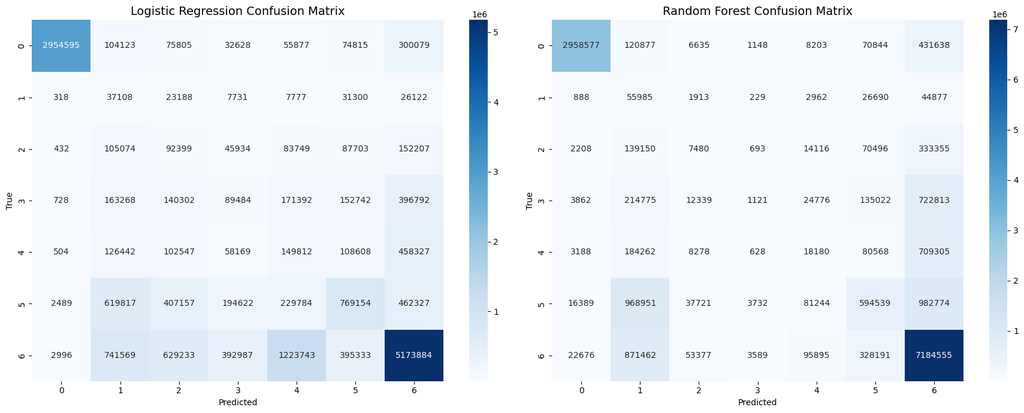

```python
models = [("Logistic Regression", lr_predictions),
          ("Random Forest", rf_predictions)]

fig, axes = plt.subplots(1, 2, figsize=(18, 7))

for ax, (name, df) in zip(axes, models):
    confusion_pdf = (
        df
        .groupBy("tip_class")
        .pivot("prediction", [0,1,2,3,4,5,6])
        .count()
        .na.fill(0)
        .orderBy("tip_class")
    ).toPandas()

    confusion_pdf = confusion_pdf.set_index("tip_class")

    sns.heatmap(confusion_pdf, annot=True, fmt="d", cmap="Blues", ax=ax)
    ax.set_title(f"{name} Confusion Matrix", fontsize=14)
    ax.set_xlabel("Predicted")
    ax.set_ylabel("True")

plt.tight_layout()
plt.show()
```

### Model Comparison Summary

After applying class weighting to address the significant class imbalance in the taxi tip classification task, both Logistic Regression (LR) and Random Forest (RF) showed notable changes in performance. However, based on the updated metrics and confusion matrices, Random Forest emerges as the more promising model for further refinement.

**Logistic Regression**, even with class weights, remains limited by its linear decision boundaries. While its weighted F1 score is comparable to Random Forest, the confusion matrix shows that LR continues to distribute many mid-range classes (1–4) across multiple predicted categories with relatively weak class separation. This indicates that LR has largely reached its performance ceiling under the current feature representation, and additional tuning is unlikely to produce substantial improvement.

### **6. Hyperparameter Tuning for the Random Forest**

```python
print("=======Start Training=======")
rf = RandomForestClassifier(
    featuresCol="features",
    labelCol="tip_class",
    weightCol="class_weight",
    seed=42
)

paramGrid = (ParamGridBuilder()
    .addGrid(rf.numTrees, [50])
    .addGrid(rf.maxDepth, [8, 16])
    .addGrid(rf.maxBins, [32, 128])
    .addGrid(rf.featureSubsetStrategy, ["sqrt", "log2"])
    .build()
)

evaluator = MulticlassClassificationEvaluator(
    labelCol="tip_class",
    predictionCol="prediction",
    metricName="f1"
)

tvs = TrainValidationSplit(
    estimator=rf,
    estimatorParamMaps=paramGrid,
    evaluator=evaluator,
    trainRatio=0.8
)

tvs_model = tvs.fit(train_df_small)

rf_best = tvs_model.bestModel
print("Best numTrees:", rf_best.getNumTrees)
print("Best maxDepth:", rf_best.getOrDefault("maxDepth"))
print("Best maxBins:", rf_best.getOrDefault("maxBins"))
print("Best featureSubsetStrategy:", rf_best.getOrDefault("featureSubsetStrategy"))
print("=======Finished Training=======")
```

```
=======Start Training=======
```

[output not shown]

[output cut: 32 more lines]

[output not shown]

```
Best numTrees: 50
Best maxDepth: 16
Best maxBins: 32
Best featureSubsetStrategy: sqrt
=======Finished Training=======
```

```python
label_counts = (
    train_df
    .groupBy("tip_class")
    .agg(F.count("*").alias("count"))
)
label_counts.show()

stats = (
    label_counts
    .agg(
        F.sum("count").alias("N"),
        F.count("*").alias("K")
    )
    .collect()[0]
)

N = stats["N"]
K = stats["K"]

label_weights = (
    label_counts
    .withColumn("class_weight", F.lit(N) / (F.lit(K) * F.col("count")))
    .select("tip_class", "class_weight")
)


train_df = train_df.join(
    broadcast(label_weights),
    on="tip_class",
    how="left"
)

train_df = train_df.cache()
train_df.show()
```

```
+---------+--------+
|tip_class|   count|
+---------+--------+
|        1|  309247|
|        6|19977734|
|        3| 2602285|
|        5| 6260658|
|        4| 2338703|
|        2| 1322932|
|        0| 8391301|
+---------+--------+
```

```
[Stage 101:>                                                        (0 + 1) / 1]
```

```
+---------+--------------------+---------------------+--------------+--------------+----------+--------------------+----------+--------------------+---------+-----------+---------------+-------------+------------------+------------+-----------+-----+-------+----------+------------+------------------…
|tip_class|tpep_pickup_datetime|tpep_dropoff_datetime|pu_location_id|do_location_id|pu_borough|             pu_zone|do_borough|             do_zone|vendor_id|ratecode_id|passenger_count|trip_distance|store_and_fwd_flag|payment_type|fare_amount|extra|mta_tax|tip_amount|tolls_amount|improvement_surcha…
+---------+--------------------+---------------------+--------------+--------------+----------+--------------------+----------+--------------------+---------+-----------+---------------+-------------+------------------+------------+-----------+-----+-------+----------+------------+------------------…
|        6| 2024-01-01 04:30:14|  2024-01-01 04:50:48|           163|           138| Manhattan|       Midtown North|    Queens|   LaGuardia Airport|        2|          1|              1|        11.56|                 N|           1|       45.7|  6.0|    0.5|     12.53|        6.94|                  …
|        3| 2024-01-01 04:32:38|  2024-01-01 04:44:23|           100|           163| Manhattan|    Garment District| Manhattan|       Midtown North|        2|          1|              1|         1.18|                 N|           1|       11.4|  1.0|    0.5|       1.6|         0.0|                  …
|        6| 2024-01-01 04:34:10|  2024-01-01 04:44:43|           163|           262| Manhattan|       Midtown North| Manhattan|      Yorkville East|        1|          1|              2|          2.7|                 N|           1|       14.9|  3.5|    0.5|      3.95|         0.0|                  …
|        0| 2024-01-01 04:34:15|  2024-01-01 04:56:41|            79|            17| Manhattan|        East Village|  Brooklyn|             Bedford|        1|          1|              1|          3.8|                 N|           2|       23.3|  3.5|    0.5|       0.0|         0.0|                  …
|        0| 2024-01-01 04:34:44|  2024-01-01 05:08:52|           114|            37| Manhattan|Greenwich Village...|  Brooklyn|      Bushwick South|        2|          1|              2|         6.63|                 N|           4|       35.9|  1.0|    0.5|       0.0|         0.0|                  …
|        2| 2024-01-01 04:35:18|  2024-01-01 04:52:26|           137|            25| Manhattan|            Kips Bay|  Brooklyn|         Boerum Hill|        2|          1|              1|         5.99|                 N|           1|       26.1|  1.0|    0.5|       2.0|         0.0|                  …
|        6| 2024-01-01 04:38:13|  2024-01-01 04:43:10|           236|           140| Manhattan|Upper East Side N...| Manhattan|     Lenox Hill East|        1|          1|              1|          1.2|                 N|           1|        7.2|  3.5|    0.5|      3.05|         0.0|                  …
|        6| 2024-01-01 04:39:53|  2024-01-01 04:46:39|           144|           158| Manhattan| Little Italy/NoLiTa| Manhattan|Meatpacking/West ...|        2|          1|              1|         1.07|                 N|           1|        8.6|  1.0|    0.5|      2.72|         0.0|                  …
|        0| 2024-01-01 04:41:05|  2024-01-01 05:02:19|            79|            48| Manhattan|        East Village| Manhattan|        Clinton East|        1|          1|              1|          3.2|                 N|           1|       19.1|  3.5|    0.5|       0.0|         0.0|                  …
|        6| 2024-01-01 04:44:58|  2024-01-01 04:57:41|           148|           141| Manhattan|     Lower East Side| Manhattan|     Lenox Hill West|        2|          1|              2|         4.23|                 N|           1|       18.4|  1.0|    0.5|      4.68|         0.0|                  …
|        4| 2024-01-01 04:46:30|  2024-01-01 05:21:51|           141|           256| Manhattan|     Lenox Hill West|  Brooklyn|Williamsburg (Sou...|        2|          1|              1|         7.71|                 N|           1|       39.4|  1.0|    0.5|       6.0|         0.0|                  …
|        3| 2024-01-01 04:46:52|  2024-01-01 04:51:27|           114|           231| Manhattan|Greenwich Village...| Manhattan|TriBeCa/Civic Center|        2|          1|              1|          1.0|                 N|           1|        7.2|  1.0|    0.5|       1.0|         0.0|                  …
|        0| 2024-01-01 04:49:27|  2024-01-01 05:01:51|            48|           125| Manhattan|        Clinton East| Manhattan|           Hudson Sq|        2|          1|              1|         2.84|                 N|           2|       14.9|  1.0|    0.5|       0.0|         0.0|                  …
```

[output cut: 9 more lines]

```python
best_maxDepth = rf_best.getOrDefault("maxDepth")
best_maxBins = rf_best.getOrDefault("maxBins")
best_fss = rf_best.getOrDefault("featureSubsetStrategy")

print("=======Fitting the whole training set=======")
rf_final = RandomForestClassifier(
    featuresCol="features",
    labelCol="tip_class",
    weightCol="class_weight",
    seed=42,
    numTrees=50,
    maxDepth=best_maxDepth,
    maxBins=best_maxBins,
    featureSubsetStrategy=best_fss,
)

rf_final_model = rf_final.fit(train_df)
print("=======Finished fitting=======")

print("=======Saving the model=======")
rf_final_model.write().overwrite().save("gs://msca-bdp-student-gcs/group_8_project/models/tip_rf_model")
print("=======Finished Saving=======")
```

```
=======Fitting the whole training set=======
```

[output not shown]

[output cut: 1421 more lines]

[output not shown]

```
=======Finished fitting=======
=======Saving the model=======
```

```
25/12/06 00:34:30 WARN org.apache.spark.scheduler.TaskSetManager: Stage 143 contains a task of very large size (2051 KiB). The maximum recommended task size is 1000 KiB.
```

```
=======Finished Saving=======
```

```python
rf_final_model = RandomForestClassificationModel.load("gs://msca-bdp-student-gcs/group_8_project/models/tip_rf_model")

rf_final_predictions = rf_final_model.transform(test_df)

rf_final_predictions = rf_final_predictions.cache()

print(rf_final_predictions.count())

rf_final_predictions.select("tip_class", "prediction").show(20, truncate=False)
```

```
25/12/06 00:41:45 WARN org.apache.spark.scheduler.DAGScheduler: Broadcasting large task binary with size 87.6 MiB
[Stage 155:>                                                        (0 + 1) / 1]
```

```
+---------+----------+
|tip_class|prediction|
+---------+----------+
|5        |1.0       |
|0        |0.0       |
|6        |2.0       |
|5        |2.0       |
|3        |1.0       |
|6        |6.0       |
|6        |1.0       |
|0        |0.0       |
|6        |6.0       |
|6        |6.0       |
|5        |6.0       |
|0        |0.0       |
|6        |6.0       |
|5        |5.0       |
|0        |0.0       |
|0        |0.0       |
|5        |5.0       |
|0        |0.0       |
|4        |2.0       |
|6        |6.0       |
+---------+----------+
only showing top 20 rows
```

```python
e = MulticlassClassificationEvaluator(labelCol="tip_class", predictionCol="prediction")

print("Random Forest - accuracy: %.3f" % e.evaluate(rf_final_predictions, {e.metricName: "accuracy"}))
print("Random Forest - f1 score: %.3f" %e.evaluate(rf_final_predictions, {e.metricName: "f1"}))
print("Random Forest - precision: %.3f" %e.evaluate(rf_final_predictions, {e.metricName: "weightedPrecision"}))
print("Random Forest - recall: %.3f" %e.evaluate(rf_final_predictions, {e.metricName: "weightedRecall"}))
```

```
25/12/06 00:43:54 WARN org.apache.spark.scheduler.DAGScheduler: Broadcasting large task binary with size 87.6 MiB
```

```
Random Forest - accuracy: 0.583
```

```
25/12/06 00:50:20 WARN org.apache.spark.scheduler.DAGScheduler: Broadcasting large task binary with size 87.6 MiB
```

```
Random Forest - f1 score: 0.597
```

```
25/12/06 00:52:39 WARN org.apache.spark.scheduler.DAGScheduler: Broadcasting large task binary with size 87.6 MiB
```

```
Random Forest - precision: 0.644
```

```
25/12/06 00:54:09 WARN org.apache.spark.scheduler.DAGScheduler: Broadcasting large task binary with size 87.6 MiB
[Stage 162:=====================================================> (31 + 1) / 32]
```

```
Random Forest - recall: 0.583
```

```
25/12/06 00:58:54 WARN org.apache.spark.scheduler.DAGScheduler: Broadcasting large task binary with size 87.6 MiB
25/12/06 01:00:10 WARN org.apache.spark.scheduler.DAGScheduler: Broadcasting large task binary with size 87.6 MiB
25/12/06 01:00:33 WARN org.apache.spark.scheduler.DAGScheduler: Broadcasting large task binary with size 87.6 MiB
25/12/06 01:00:36 WARN org.apache.spark.scheduler.DAGScheduler: Broadcasting large task binary with size 87.6 MiB
25/12/06 01:00:44 WARN org.apache.spark.scheduler.DAGScheduler: Broadcasting large task binary with size 87.6 MiB
```

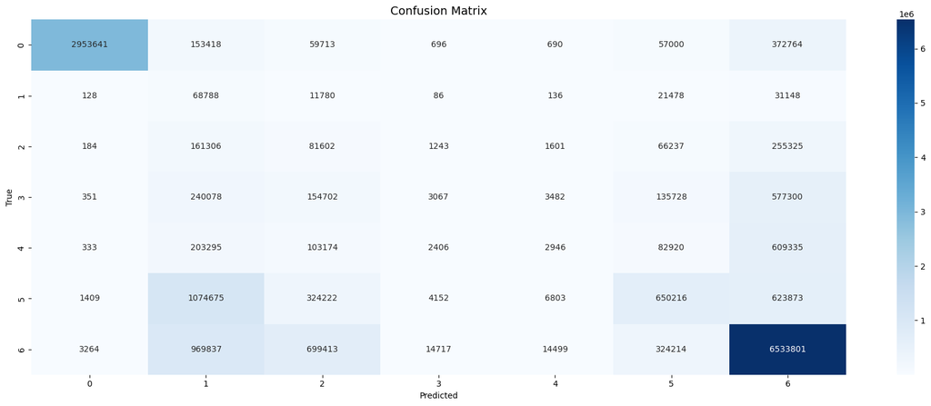

```python
confusion_pdf = (
    rf_final_predictions
    .groupBy("tip_class")
    .pivot("prediction", [0, 1, 2, 3, 4, 5, 6])
    .count()
    .na.fill(0)
    .orderBy("tip_class")
).toPandas()

confusion_pdf = confusion_pdf.set_index("tip_class")

fig, ax = plt.subplots(figsize=(18, 7))

sns.heatmap(
    confusion_pdf,
    annot=True,
    fmt="d",
    cmap="Blues",
    ax=ax
)

ax.set_title(f"Confusion Matrix", fontsize=14)
ax.set_xlabel("Predicted")
ax.set_ylabel("True")

plt.tight_layout()
plt.show()
```

**Conclusion: Tuned Multinomial Random Forest Classifier Performance**

**Model comparison – Logistic Regression, baseline Random Forest, and tuned Random Forest**

We benchmarked three models for the 7-class tip-tier prediction task: a multinomial logistic regression, a baseline random forest, and a random forest tuned with TrainValidationSplit. Overall, the random forests achieve slightly better headline metrics than the linear baseline, but all three models highlight how noisy and difficult individual tip behavior is to predict.

The **baseline Random Forest** delivers the strongest top-line accuracy and F1 on the test set (accuracy ≈ **0.61**, weighted F1 ≈ **0.60**, precision ≈ **0.62**, recall ≈ **0.61**). Its confusion matrix shows that it is very good at identifying the extreme classes (no-tip and the highest tip tier), but it often collapses mid-range trips (classes 2–4) into either low tips (class 1) or very high tips (class 6). In other words, it captures “low vs. very high” tipping reasonably well, but struggles to distinguish finer-grained intermediate bins.

After **hyperparameter tuning**, the **tuned Random Forest** achieves a very similar weighted F1 score (**0.597**, essentially unchanged) but trades off accuracy for precision: test accuracy drops from **0.613** to **0.583**, while weighted precision increases from **0.617** to **0.644**. In the tuned confusion matrix, the model is less aggressive about predicting the highest tier (class 6) and reallocates more observations into lower and mid-range bins (especially classes 1–2). This makes high-tip predictions more conservative and reliable (fewer false positives), but reduces recall for truly generous tippers and slightly lowers overall accuracy.

### **7. Post Evaluation**

```python
pred = rf_final_predictions.cache()

print(pred.count())
```

```
25/12/06 01:09:08 WARN org.apache.spark.sql.execution.CacheManager: Asked to cache already cached data.
25/12/06 01:09:10 WARN org.apache.spark.scheduler.DAGScheduler: Broadcasting large task binary with size 87.6 MiB
[Stage 193:=====================================================> (31 + 1) / 32]
```

```
17663176
```

```python
pred.printSchema()
```

```
root
 |-- tpep_pickup_datetime: timestamp (nullable = true)
 |-- tpep_dropoff_datetime: timestamp (nullable = true)
 |-- pu_location_id: integer (nullable = true)
 |-- do_location_id: integer (nullable = true)
 |-- pu_borough: string (nullable = true)
 |-- pu_zone: string (nullable = true)
 |-- do_borough: string (nullable = true)
 |-- do_zone: string (nullable = true)
 |-- vendor_id: integer (nullable = true)
 |-- ratecode_id: integer (nullable = true)
 |-- passenger_count: integer (nullable = true)
 |-- trip_distance: double (nullable = true)
 |-- store_and_fwd_flag: string (nullable = true)
 |-- payment_type: integer (nullable = true)
 |-- fare_amount: double (nullable = true)
 |-- extra: double (nullable = true)
 |-- mta_tax: double (nullable = true)
 |-- tip_amount: double (nullable = true)
 |-- tolls_amount: double (nullable = true)
 |-- improvement_surcharge: double (nullable = true)
 |-- congestion_surcharge: double (nullable = true)
 |-- airport_fee: double (nullable = true)
 |-- total_amount: double (nullable = true)
 |-- pu_temp: double (nullable = true)
 |-- pu_dwpt: double (nullable = true)
 |-- pu_rhum: double (nullable = true)
 |-- pu_prcp: double (nullable = true)
 |-- pu_wdir: double (nullable = true)
 |-- pu_wspd: double (nullable = true)
 |-- pu_pres: double (nullable = true)
 |-- pu_coco: double (nullable = true)
 |-- do_temp: double (nullable = true)
 |-- do_dwpt: double (nullable = true)
 |-- do_rhum: double (nullable = true)
 |-- do_prcp: double (nullable = true)
 |-- do_wdir: double (nullable = true)
 |-- do_wspd: double (nullable = true)
 |-- do_pres: double (nullable = true)
 |-- do_coco: double (nullable = true)
```

[output cut: 59 more lines]

```
 |-- payment_type_vec: vector (nullable = true)
 |-- pu_borough_idx: double (nullable = false)
 |-- pu_borough_vec: vector (nullable = true)
 |-- pu_zone_idx: double (nullable = false)
 |-- pu_zone_vec: vector (nullable = true)
 |-- do_borough_idx: double (nullable = false)
 |-- do_borough_vec: vector (nullable = true)
 |-- do_zone_idx: double (nullable = false)
 |-- do_zone_vec: vector (nullable = true)
 |-- store_and_fwd_flag_idx: double (nullable = false)
 |-- store_and_fwd_flag_vec: vector (nullable = true)
 |-- features: vector (nullable = true)
 |-- rawPrediction: vector (nullable = true)
 |-- probability: vector (nullable = true)
 |-- prediction: double (nullable = false)
```

```python
pred = (
    pred
    .withColumn("is_high_tip", (F.col("tip_class") >= 5).cast("int"))
    .withColumn("pred_high_tip", (F.col("prediction") >= 5).cast("int"))
    .withColumn("hour", F.hour("tpep_pickup_datetime"))
)
pred.select("is_high_tip", "pred_high_tip", "hour").show(10)
```

```
25/12/06 01:12:59 WARN org.apache.spark.scheduler.DAGScheduler: Broadcasting large task binary with size 87.6 MiB
[Stage 196:>                                                        (0 + 1) / 1]
```

```
+-----------+-------------+----+
|is_high_tip|pred_high_tip|hour|
+-----------+-------------+----+
|          1|            0|   4|
|          0|            0|   4|
|          1|            0|   4|
|          1|            0|   4|
|          0|            0|   4|
|          1|            1|   4|
|          1|            0|   4|
|          0|            0|   4|
|          1|            1|   4|
|          1|            1|   4|
+-----------+-------------+----+
only showing top 10 rows
```

```
25/12/06 01:15:07 WARN org.apache.spark.scheduler.DAGScheduler: Broadcasting large task binary with size 87.6 MiB
25/12/06 01:15:31 WARN org.apache.spark.scheduler.DAGScheduler: Broadcasting large task binary with size 87.6 MiB
25/12/06 01:15:34 WARN org.apache.spark.scheduler.DAGScheduler: Broadcasting large task binary with size 87.6 MiB
25/12/06 01:15:41 WARN org.apache.spark.scheduler.DAGScheduler: Broadcasting large task binary with size 87.6 MiB
```

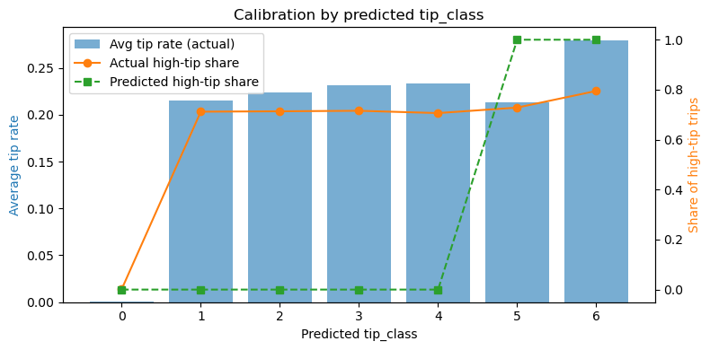

```python
pred_stats_pdf = (
    pred
    .groupBy("prediction")
    .agg(
        F.count("*").alias("n_trips"),
        F.avg("tip_rate").alias("avg_tip_rate"),
        F.avg("is_high_tip").alias("actual_high_tip_share"),
        F.avg("pred_high_tip").alias("pred_high_tip_share")
    )
    .orderBy("prediction")
).toPandas()


fig, ax1 = plt.subplots(figsize=(8, 4))

x = pred_stats_pdf["prediction"].values

ax1.bar(x, pred_stats_pdf["avg_tip_rate"], alpha=0.6, label="Avg tip rate (actual)")
ax1.set_xlabel("Predicted tip_class")
ax1.set_ylabel("Average tip rate", color="C0")

ax2 = ax1.twinx()
ax2.plot(x, pred_stats_pdf["actual_high_tip_share"], marker="o", label="Actual high-tip share", color="C1")
ax2.plot(x, pred_stats_pdf["pred_high_tip_share"], marker="s", linestyle="--", label="Predicted high-tip share", color="C2")
ax2.set_ylabel("Share of high-tip trips", color="C1")

lines, labels = ax1.get_legend_handles_labels()
lines2, labels2 = ax2.get_legend_handles_labels()
ax2.legend(lines + lines2, labels + labels2, loc="upper left")

plt.title("Calibration by predicted tip_class")
plt.tight_layout()
plt.show()
```

However, when we collapse the 7 classes into a binary “high-tip vs non-high-tip” outcome, using tip_class ≥ 5 as the threshold, we see that the actual share of high-tip trips is already very high across predicted classes 1–4 – around 70%. In other words, once we leave the 0 bucket, most trips are actually high-tip in our labeling, and the separation between the middle tiers is limited.

This suggests that while the 7-class model captures an ordinal structure — higher predictions correspond to higher average tips — our current definition of “high tip” may be too strict or misaligned with the natural structure of the data. In future work, we would likely re-define the target into fewer, more meaningful groups (for example: no tip / average tip / generous tip) rather than trying to fully separate all 7 fine-grained bins.

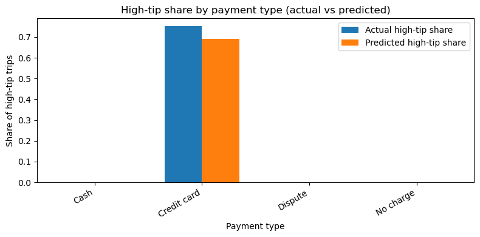

```python
import numpy as np
pay_pdf = (
    pred
    .groupBy("payment_type_cat")
    .agg(
        F.count("*").alias("n_trips"),
        F.avg("is_high_tip").alias("actual_high_tip_share"),
        F.avg("pred_high_tip").alias("pred_high_tip_share")
    )
    .orderBy("payment_type_cat")
).toPandas()

x = np.arange(len(pay_pdf))
width = 0.35

plt.figure(figsize=(8, 4))
plt.bar(x - width/2, pay_pdf["actual_high_tip_share"], width, label="Actual high-tip share")
plt.bar(x + width/2, pay_pdf["pred_high_tip_share"], width, label="Predicted high-tip share")

plt.xticks(x, pay_pdf["payment_type_cat"], rotation=30, ha="right")
plt.ylabel("Share of high-tip trips")
plt.xlabel("Payment type")
plt.title("High-tip share by payment type (actual vs predicted)")
plt.legend()
plt.tight_layout()
plt.show()
```

This chart compares the actual and predicted share of high-tip trips by payment type.

We see that practically all high tips in our data occur on credit-card transactions. For cash, dispute, and no-charge trips, both the actual and predicted high-tip share are essentially zero. This is consistent with how the data are collected: cash tips are often not recorded on the meter, and disputed or free rides rarely include tips.

The model captures this pattern very well. It does not hallucinate high tips for non-card payments, and for credit-card trips it predicts a high-tip probability around 69%, which is close to the observed rate of about 74%, although slightly conservative.

This implies that our tip prediction model is mainly informative for card payments, while tip behavior for cash and special cases would require additional data or a different modeling approach.

```
25/12/06 01:22:34 WARN org.apache.spark.scheduler.DAGScheduler: Broadcasting large task binary with size 87.6 MiB
25/12/06 01:22:58 WARN org.apache.spark.scheduler.DAGScheduler: Broadcasting large task binary with size 87.6 MiB
25/12/06 01:23:00 WARN org.apache.spark.scheduler.DAGScheduler: Broadcasting large task binary with size 87.6 MiB
25/12/06 01:23:10 WARN org.apache.spark.scheduler.DAGScheduler: Broadcasting large task binary with size 87.6 MiB
```

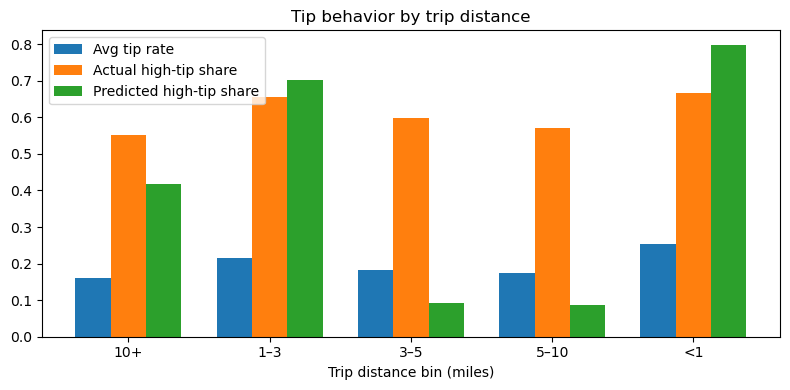

```python
df_dist = pred.withColumn(
    "distance_bin",
    F.when(F.col("trip_distance") < 1, "<1")
     .when(F.col("trip_distance") < 3, "1–3")
     .when(F.col("trip_distance") < 5, "3–5")
     .when(F.col("trip_distance") < 10, "5–10")
     .otherwise("10+")
)

dist_pdf = (
    df_dist
    .groupBy("distance_bin")
    .agg(
        F.count("*").alias("n_trips"),
        F.avg("tip_rate").alias("avg_tip_rate"),
        F.avg("is_high_tip").alias("actual_high_tip_share"),
        F.avg("pred_high_tip").alias("pred_high_tip_share")
    )
    .orderBy("distance_bin")
).toPandas()

x = np.arange(len(dist_pdf))
width = 0.25

plt.figure(figsize=(8, 4))
plt.bar(x - width, dist_pdf["avg_tip_rate"], width, label="Avg tip rate")
plt.bar(x, dist_pdf["actual_high_tip_share"], width, label="Actual high-tip share")
plt.bar(x + width, dist_pdf["pred_high_tip_share"], width, label="Predicted high-tip share")

plt.xticks(x, dist_pdf["distance_bin"])
plt.xlabel("Trip distance bin (miles)")
plt.title("Tip behavior by trip distance")
plt.legend()
plt.tight_layout()
plt.show()
```

This chart looks at tipping behavior across trip distance bins.

On the blue bars, we see that short trips – especially under 1 mile and 1–3 miles – have the highest average tip rates. As distance increases, the average tip percentage declines slightly, which is intuitive: riders may be less willing to tip a high percentage on very long rides.

The orange bars show the actual share of high-tip trips in each distance bin. Interestingly, even for medium and long trips (3–10 miles), more than half of the rides are still labeled as high-tip. So in reality, high tips are not limited to short distances.

This indicates a systematic bias in the model with respect to trip distance: it tends to treat medium-length trips as “low-tip” even though the data suggest otherwise. From a business standpoint, this means we should be careful about using the model to deprioritize or penalize medium-distance trips; they are actually quite valuable in terms of tipping, even if the model doesn’t fully recognize that.

```
25/12/06 01:25:58 WARN org.apache.spark.scheduler.DAGScheduler: Broadcasting large task binary with size 87.6 MiB
25/12/06 01:26:21 WARN org.apache.spark.scheduler.DAGScheduler: Broadcasting large task binary with size 87.6 MiB
25/12/06 01:26:29 WARN org.apache.spark.scheduler.DAGScheduler: Broadcasting large task binary with size 87.6 MiB
25/12/06 01:26:45 WARN org.apache.spark.scheduler.DAGScheduler: Broadcasting large task binary with size 87.6 MiB
```

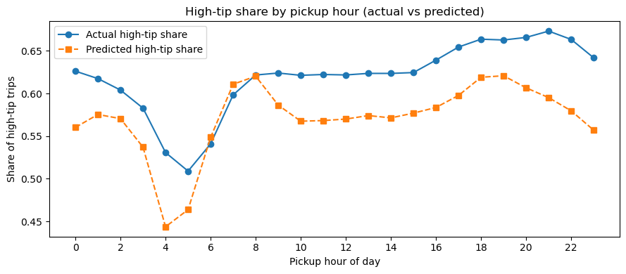

```python
hour_pdf = (
    pred
    .groupBy("hour")
    .agg(
        F.count("*").alias("n_trips"),
        F.avg("tip_rate").alias("avg_tip_rate"),
        F.avg("is_high_tip").alias("actual_high_tip_share"),
        F.avg("pred_high_tip").alias("pred_high_tip_share")
    )
    .orderBy("hour")
).toPandas()

plt.figure(figsize=(9, 4))
plt.plot(hour_pdf["hour"], hour_pdf["actual_high_tip_share"], marker="o", label="Actual high-tip share")
plt.plot(hour_pdf["hour"], hour_pdf["pred_high_tip_share"], marker="s", linestyle="--", label="Predicted high-tip share")
plt.xlabel("Pickup hour of day")
plt.ylabel("Share of high-tip trips")
plt.title("High-tip share by pickup hour (actual vs predicted)")
plt.xticks(range(0, 24, 2))
plt.legend()
plt.tight_layout()
plt.show()
```

This chart shows how the share of high-tip trips evolves over the 24-hour day, comparing the actual data with what the model predicts.

On the blue line, we see a clear daily pattern: high-tip rates are lowest in the early morning hours around 4–5am, then rise sharply during the morning commute and stay relatively stable throughout the daytime, before peaking again in the evening around 6–9pm. In other words, riders are more generous during daytime and evening trips, while early-morning trips are more conservative on tipping.

This suggests that the model is picking up the time-of-day signal, but it tends to underestimate how generous riders actually are, especially during the evening peaks. For decision-making, this means we can rely on the model for relative comparisons between time slots, but we should be cautious about treating the predicted probabilities as perfectly calibrated in absolute terms.

```
25/12/06 01:29:27 WARN org.apache.spark.scheduler.DAGScheduler: Broadcasting large task binary with size 87.6 MiB
25/12/06 01:29:55 WARN org.apache.spark.scheduler.DAGScheduler: Broadcasting large task binary with size 87.6 MiB
25/12/06 01:29:58 WARN org.apache.spark.scheduler.DAGScheduler: Broadcasting large task binary with size 87.6 MiB
25/12/06 01:30:06 WARN org.apache.spark.scheduler.DAGScheduler: Broadcasting large task binary with size 87.6 MiB
```

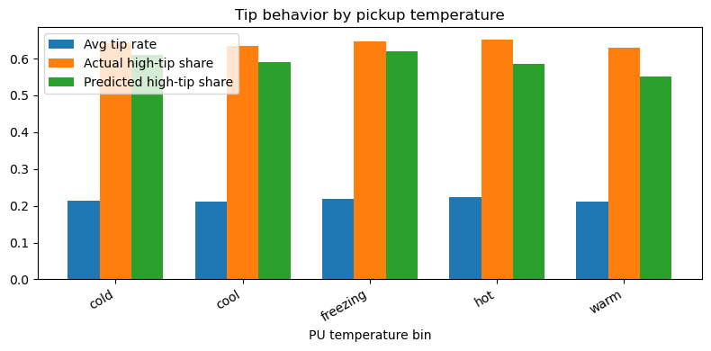

```python
temp_pdf = (
    pred
    .groupBy("pu_temp_bin")
    .agg(
        F.count("*").alias("n_trips"),
        F.avg("tip_rate").alias("avg_tip_rate"),
        F.avg("is_high_tip").alias("actual_high_tip_share"),
        F.avg("pred_high_tip").alias("pred_high_tip_share")
    )
    .orderBy("pu_temp_bin")
).toPandas()

x = np.arange(len(temp_pdf))
width = 0.25

plt.figure(figsize=(8, 4))
plt.bar(x - width, temp_pdf["avg_tip_rate"], width, label="Avg tip rate")
plt.bar(x, temp_pdf["actual_high_tip_share"], width, label="Actual high-tip share")
plt.bar(x + width, temp_pdf["pred_high_tip_share"], width, label="Predicted high-tip share")

plt.xticks(x, temp_pdf["pu_temp_bin"], rotation=30, ha="right")
plt.xlabel("PU temperature bin")
plt.title("Tip behavior by pickup temperature")
plt.legend()
plt.tight_layout()
plt.show()
```

This chart looks at tipping behavior across pickup temperature bins.

First, the blue bars show that the average tip rate is fairly stable across temperature conditions, hovering around 21–23%. So temperature does not radically change how much people tip as a percentage of the fare.

The orange bars show the actual share of high-tip trips. Here we see only a mild pattern: extreme conditions – especially freezing and hot weather – are associated with slightly higher high-tip rates, while more moderate “cold/cool/warm” bins sit a bit lower. In other words, riders may be a bit more generous when the weather is unpleasant, but the effect size is modest.

Overall, this suggests that temperature has a secondary influence on tipping compared to other drivers like time of day, distance, and payment type. The model uses temperature as a weak signal, but its impact on predictions is intentionally dampened, which is reasonable for a noisy and relatively small effect.

```
25/12/06 01:36:49 WARN org.apache.spark.scheduler.DAGScheduler: Broadcasting large task binary with size 87.6 MiB
25/12/06 01:37:08 WARN org.apache.spark.scheduler.DAGScheduler: Broadcasting large task binary with size 87.6 MiB
```

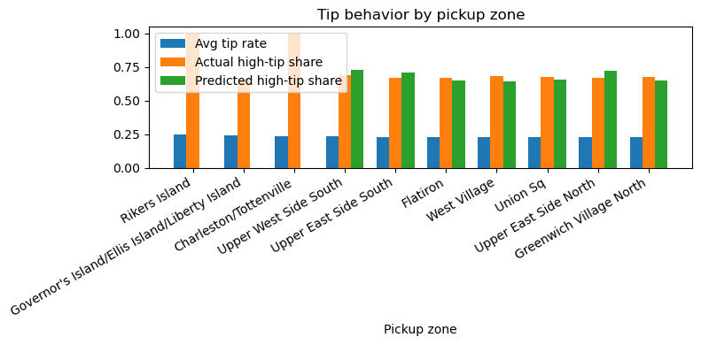

```python
zone_pdf = (
    pred
    .groupBy("pu_zone")
    .agg(
        F.count("*").alias("n_trips"),
        F.avg("tip_rate").alias("avg_tip_rate"),
        F.avg("is_high_tip").alias("actual_high_tip_share"),
        F.avg("pred_high_tip").alias("pred_high_tip_share")
    )
    .orderBy("avg_tip_rate", ascending=[0])
    .limit(10)
).toPandas()

x = np.arange(len(zone_pdf))
width = 0.25

plt.figure(figsize=(8, 4))
plt.bar(x - width, zone_pdf["avg_tip_rate"], width, label="Avg tip rate")
plt.bar(x, zone_pdf["actual_high_tip_share"], width, label="Actual high-tip share")
plt.bar(x + width, zone_pdf["pred_high_tip_share"], width, label="Predicted high-tip share")

plt.xticks(x, zone_pdf["pu_zone"], rotation=30, ha="right")
plt.xlabel("Pickup zone")
plt.title("Tip behavior by pickup zone")
plt.legend()
plt.tight_layout()
plt.show()
```

This chart shows tipping behavior across several pickup zones in New York.

For most Manhattan neighborhoods – such as the Upper West Side, Upper East Side, Flatiron, West Village, and Union Square – both the average tip rate and the share of high-tip trips are consistently high. The model’s predicted high-tip share (green bars) is very close to the actual share (orange bars), which means it has learned that these zones are high-value tipping areas and is well calibrated there.

Overall, this suggests that the model captures geographic patterns in tipping quite well for mainstream zones, but we should be cautious when interpreting predictions for rare or unusual pickup locations where the data are sparse.